[figure not shown]

# **Análisis Inferencial de la Satisfacción Turística**

#### Alumna: Erika Samara Alvares Angelim

#### Profesor: Gustavo Néstor Fontana Riera

#### Asignatura: Análisis e Interpretación de Datos

#### Fecha: 18 de junio de 2025

# 1 Introducción

Este cuaderno desarrolla la Actividad 3 del laboratorio de estadística inferencial. Se analizan dos situaciones aplicadas al sector turístico:

- Determinar si el nivel medio de satisfacción de los turistas supera un valor de referencia.
- Evaluar si existe diferencia significativa entre grupos con y sin accesibilidad.

También se documentan las decisiones estadísticas y se justifica cada paso de análisis.

# 2 Configurar entorno

# 3 Carga de paquetes necesarios

Se utiliza `pacman` para instalar y cargar de forma más eficiente múltiples paquetes necesarios. Esta librería evita errores por duplicidad y permite mantener el código limpio.

💡 Comentario técnico: Evitamos conflictos con library() y require().

```r
if (!require("pacman")) install.packages("pacman")
pacman::p_load(tidyverse, skimr, kableExtra, janitor, modeest, raster, moments, ggcorrplot, read_csv, ggplot2, dplyr, devtools, stringr)
```

# 4 Carga y limpieza inicial de los datos

## 4.1 Cargar datos desde URL pública

```r
url_datos <- "https://raw.githubusercontent.com/ea-analisisdatos/unir/refs/heads/main/datos/tourism_dataset_5000.csv"
datos <- read_csv(url_datos)
```

## 4.2 Visualizar primeras líneas del dataset original

```r
head(datos, 5)
```

| Tourist ID | Age | Interests | Preferred Tour Duration | Accessibility | Site Name | Sites Visited | Tour Duration | Route ID | Tourist Rating | System Response Time | Recommendation Accuracy | VR Experience Quality | Satisfaction |
| --- | --- | --- | --- | --- | --- | --- | --- | --- | --- | --- | --- | --- | --- |
| 1 | 48 | ['Architecture', 'Art', 'History'] | 5 | FALSE | Eiffel Tower | ['Eiffel Tower', 'Great Wall of China', 'Taj Mahal'] | 7 | 1000 | 1.6 | 3.73 | 97 | 4.5 | 3 |
| 2 | 37 | ['Cultural', 'Nature'] | 6 | FALSE | Colosseum | ['Great Wall of China'] | 1 | 2000 | 2.6 | 2.89 | 90 | 4.5 | 3 |
| 3 | 43 | ['History', 'Art', 'Architecture'] | 6 | TRUE | Machu Picchu | ['Eiffel Tower'] | 2 | 3000 | 1.7 | 2.22 | 94 | 4.7 | 3 |
| 4 | 46 | ['Cultural', 'Art', 'Architecture'] | 8 | FALSE | Colosseum | ['Machu Picchu', 'Taj Mahal'] | 5 | 4000 | 2.0 | 2.34 | 92 | 4.7 | 3 |
| 5 | 53 | ['Architecture', 'Art'] | 5 | TRUE | Colosseum | ['Machu Picchu', 'Taj Mahal', 'Great Wall of China'] | 7 | 5000 | 3.7 | 2.00 | 96 | 4.8 | 4 |

## 4.3 Limpieza de nombres de columnas

Este paso, `janitor` convierte los nombres compuestos de las columnas en formato snake_case, facilitando su uso en R.

```r
datos <- janitor::clean_names(datos)
head(datos, 5)
```

| tourist_id | age | interests | preferred_tour_duration | accessibility | site_name | sites_visited | tour_duration | route_id | tourist_rating | system_response_time | recommendation_accuracy | vr_experience_quality | satisfaction |
| --- | --- | --- | --- | --- | --- | --- | --- | --- | --- | --- | --- | --- | --- |
| 1 | 48 | ['Architecture', 'Art', 'History'] | 5 | FALSE | Eiffel Tower | ['Eiffel Tower', 'Great Wall of China', 'Taj Mahal'] | 7 | 1000 | 1.6 | 3.73 | 97 | 4.5 | 3 |
| 2 | 37 | ['Cultural', 'Nature'] | 6 | FALSE | Colosseum | ['Great Wall of China'] | 1 | 2000 | 2.6 | 2.89 | 90 | 4.5 | 3 |
| 3 | 43 | ['History', 'Art', 'Architecture'] | 6 | TRUE | Machu Picchu | ['Eiffel Tower'] | 2 | 3000 | 1.7 | 2.22 | 94 | 4.7 | 3 |
| 4 | 46 | ['Cultural', 'Art', 'Architecture'] | 8 | FALSE | Colosseum | ['Machu Picchu', 'Taj Mahal'] | 5 | 4000 | 2.0 | 2.34 | 92 | 4.7 | 3 |
| 5 | 53 | ['Architecture', 'Art'] | 5 | TRUE | Colosseum | ['Machu Picchu', 'Taj Mahal', 'Great Wall of China'] | 7 | 5000 | 3.7 | 2.00 | 96 | 4.8 | 4 |

# 5 Estructura general del dataset

```r
glimpse(datos)
```

```
## Rows: 5,000
## Columns: 14
## $ tourist_id              <dbl> 1, 2, 3, 4, 5, 6, 7, 8, 9, 10, 11, 12, 13, 14,…
## $ age                     <dbl> 48, 37, 43, 46, 53, 50, 61, 23, 34, 61, 27, 37…
## $ interests               <chr> "['Architecture', 'Art', 'History']", "['Cultu…
## $ preferred_tour_duration <dbl> 5, 6, 6, 8, 5, 4, 7, 5, 5, 5, 4, 3, 8, 8, 4, 7…
## $ accessibility           <lgl> FALSE, FALSE, TRUE, FALSE, TRUE, FALSE, FALSE,…
## $ site_name               <chr> "Eiffel Tower", "Colosseum", "Machu Picchu", "…
## $ sites_visited           <chr> "['Eiffel Tower', 'Great Wall of China', 'Taj …
## $ tour_duration           <dbl> 7, 1, 2, 5, 7, 4, 6, 2, 6, 6, 6, 5, 6, 1, 6, 8…
## $ route_id                <dbl> 1000, 2000, 3000, 4000, 5000, 6000, 7000, 8000…
## $ tourist_rating          <dbl> 1.6, 2.6, 1.7, 2.0, 3.7, 2.2, 4.1, 2.8, 4.0, 3…
## $ system_response_time    <dbl> 3.73, 2.89, 2.22, 2.34, 2.00, 3.74, 4.66, 4.84…
## $ recommendation_accuracy <dbl> 97, 90, 94, 92, 96, 99, 93, 91, 95, 95, 99, 10…
## $ vr_experience_quality   <dbl> 4.5, 4.5, 4.7, 4.7, 4.8, 4.5, 4.5, 4.9, 4.4, 4…
## $ satisfaction            <dbl> 3, 3, 3, 3, 4, 3, 4, 3, 4, 4, 3, 3, 3, 4, 3, 3…
```

## 5.1 Diccionario de datos

```r
tribble(
  ~Variable, ~Descripción,
  "tourist_id", "Identificador único del turista",
  "age", "Edad del turista",
  "interests", "Temas de interés",
  "preferred_tour_duration", "Duración preferida del tour (días)",
  "accessibility", "Requiere accesibilidad (TRUE/FALSE)",
  "site_name", "Nombre del sitio visitado",
  "sites_visited", "Lista de sitios visitados",
  "tour_duration", "Duración del tour realizado",
  "route_id", "ID de la ruta turística",
  "tourist_rating", "Valoración del turista (1-5)",
  "system_response_time", "Tiempo de respuesta del sistema",
  "recommendation_accuracy", "Precisión de recomendaciones (%)",
  "vr_experience_quality", "Calidad de experiencia VR (1-5)",
  "satisfaction", "Satisfacción general (1-5)"
) %>%
  kable(format = "html", caption = "Diccionario de datos") %>%
  kable_styling(full_width = FALSE)
```

Diccionario de datos

| Variable | Descripción |
| --- | --- |
| tourist_id | Identificador único del turista |
| age | Edad del turista |
| interests | Temas de interés |
| preferred_tour_duration | Duración preferida del tour (días) |
| accessibility | Requiere accesibilidad (TRUE/FALSE) |
| site_name | Nombre del sitio visitado |
| sites_visited | Lista de sitios visitados |
| tour_duration | Duración del tour realizado |
| route_id | ID de la ruta turística |
| tourist_rating | Valoración del turista (1-5) |
| system_response_time | Tiempo de respuesta del sistema |
| recommendation_accuracy | Precisión de recomendaciones (%) |
| vr_experience_quality | Calidad de experiencia VR (1-5) |
| satisfaction | Satisfacción general (1-5) |

## 5.2 Verificación de tipos de variables

```r
tabla_variables <- tibble(
  Variable = names(datos),
  Tipo = sapply(datos, function(x) class(x)[1])
)
kable(tabla_variables, format = "html", caption = "Tipos de variables") %>%
  kable_styling(full_width = FALSE, bootstrap_options = c("striped", "hover", "condensed"))
```

Tipos de variables

| Variable | Tipo |
| --- | --- |
| tourist_id | numeric |
| age | numeric |
| interests | character |
| preferred_tour_duration | numeric |
| accessibility | logical |
| site_name | character |
| sites_visited | character |
| tour_duration | numeric |
| route_id | numeric |
| tourist_rating | numeric |
| system_response_time | numeric |
| recommendation_accuracy | numeric |
| vr_experience_quality | numeric |
| satisfaction | numeric |

# 6 Evaluación de calidad y estadísticos descriptivos

## 6.1 Verificar valores nulos

```r
colSums(is.na(datos))
```

```
##              tourist_id                     age               interests
##                       0                       0                       0
## preferred_tour_duration           accessibility               site_name
##                       0                       0                       0
##           sites_visited           tour_duration                route_id
##                       0                       0                       0
##          tourist_rating    system_response_time recommendation_accuracy
##                       0                       0                       0
##   vr_experience_quality            satisfaction
##                       0                       0
```

## 6.2 Resumen general con skimr

```r
skim(datos)
```

Data summary

| Name | datos |
| --- | --- |
| Number of rows | 5000 |
| Number of columns | 14 |
| _______________________ |  |
| Column type frequency: |  |
| character | 3 |
| logical | 1 |
| numeric | 10 |
| ________________________ |  |
| Group variables | None |

**Variable type: character**

| skim_variable | n_missing | complete_rate | min | max | empty | n_unique | whitespace |
| --- | --- | --- | --- | --- | --- | --- | --- |
| interests | 0 | 1 | 7 | 39 | 0 | 85 | 0 |
| site_name | 0 | 1 | 9 | 19 | 0 | 5 | 0 |
| sites_visited | 0 | 1 | 13 | 55 | 0 | 85 | 0 |

**Variable type: logical**

| skim_variable | n_missing | complete_rate | mean | count |
| --- | --- | --- | --- | --- |
| accessibility | 0 | 1 | 0.49 | FAL: 2531, TRU: 2469 |

**Variable type: numeric**

| skim_variable | n_missing | complete_rate | mean | sd | p0 | p25 | p50 | p75 | p100 | hist |
| --- | --- | --- | --- | --- | --- | --- | --- | --- | --- | --- |
| tourist_id | 0 | 1 | 2500.50 | 1443.52 | 1.0 | 1250.75 | 2500.50 | 3750.25 | 5000 | ▇▇▇▇▇ |
| age | 0 | 1 | 43.89 | 15.27 | 18.0 | 30.00 | 44.00 | 57.00 | 70 | ▇▇▇▇▇ |
| preferred_tour_duration | 0 | 1 | 5.52 | 1.71 | 3.0 | 4.00 | 6.00 | 7.00 | 8 | ▇▃▅▅▅ |
| tour_duration | 0 | 1 | 3.98 | 2.00 | 1.0 | 2.00 | 4.00 | 5.00 | 9 | ▆▇▃▅▁ |
| route_id | 0 | 1 | 2500500.00 | 1443520.00 | 1000.0 | 1250750.00 | 2500500.00 | 3750250.00 | 5000000 | ▇▇▇▇▇ |
| tourist_rating | 0 | 1 | 3.00 | 1.16 | 1.0 | 2.00 | 3.00 | 4.00 | 5 | ▇▇▇▇▇ |
| system_response_time | 0 | 1 | 3.24 | 1.02 | 1.5 | 2.36 | 3.23 | 4.13 | 5 | ▇▇▇▇▇ |
| recommendation_accuracy | 0 | 1 | 92.49 | 4.62 | 85.0 | 88.00 | 92.00 | 97.00 | 100 | ▇▆▆▆▆ |
| vr_experience_quality | 0 | 1 | 4.49 | 0.29 | 4.0 | 4.20 | 4.50 | 4.70 | 5 | ▇▆▆▆▅ |
| satisfaction | 0 | 1 | 3.53 | 0.74 | 3.0 | 3.00 | 3.00 | 4.00 | 5 | ▇▁▃▁▂ |

Observaciones:

- La variable satisfaction tiene una media de aproximadamente 3.53, con moda 3.
- No existen valores faltantes.
- La variable tourist_rating presenta correlación fuerte con satisfaction.

# 7 **Parte 1: ¿La satisfacción media es significativamente mayor que 3?**

Aquí se analiza si la satisfacción media de los turistas supera el umbral de 3 puntos, considerado como un valor positivo.

## 7.1 Contexto del problema

Se analiza la satisfacción general de los turistas utilizando una escala de 1 a 5. Se desea verificar si la media poblacional supera el umbral de 3 puntos, valor considerado como referencia para experiencias positivas en este dataset.

## 7.2 Justificación estadística

Se aplicará una prueba t de una muestra, que evalúa si la media muestral difiere significativamente de un valor de referencia (μ₀ = 3).

**Hipótesis:**

- **H₀: μ ≤ 3** (la satisfacción media no supera 3)
- **H₁: μ > 3** (la satisfacción media es superior a 3)

## 7.3 Análisis descriptivo y gráfico

```r
summary(datos$satisfaction)
```

```
##    Min. 1st Qu.  Median    Mean 3rd Qu.    Max.
##   3.000   3.000   3.000   3.534   4.000   5.000
```

### 7.3.1 Visualización

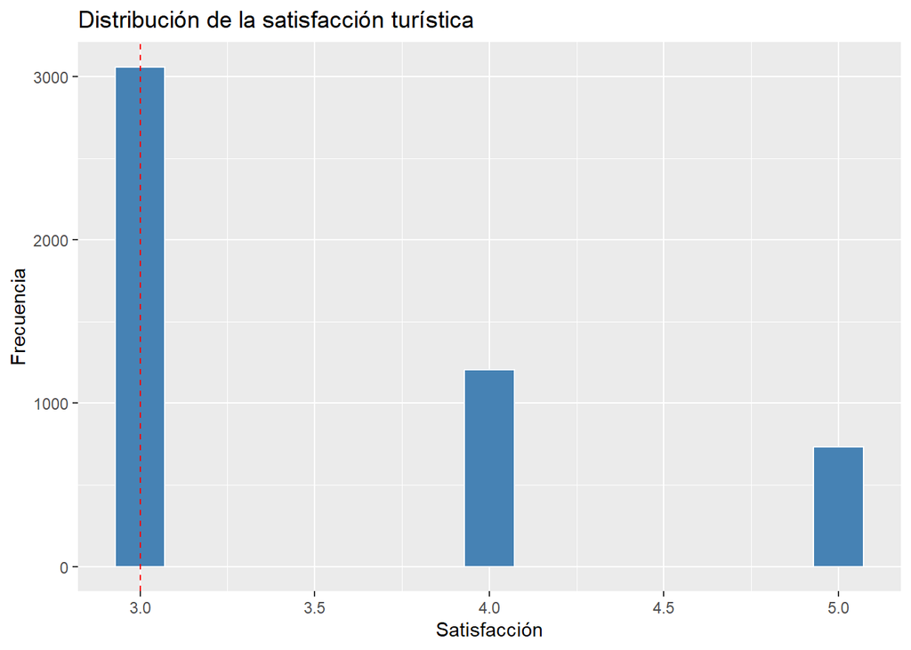

```r
ggplot(datos, aes(x = satisfaction)) +
  geom_histogram(bins = 15, fill = "steelblue", color = "white") +
  geom_vline(xintercept = 3, linetype = "dashed", color = "red") +
  labs(title = "Distribución de la satisfacción turística", x = "Satisfacción", y = "Frecuencia")
```

## 7.4 Contraste de hipótesis

```r
t.test(datos$satisfaction, mu = 3, alternative = "greater")
```

```
##
##  One Sample t-test
##
## data:  datos$satisfaction
## t = 51.321, df = 4999, p-value < 0.00000000000000022
## alternative hypothesis: true mean is greater than 3
## 95 percent confidence interval:
##  3.517076      Inf
## sample estimates:
## mean of x
##    3.5342
```

# 8 **Parte 2: ¿Existen diferencias según accesibilidad?**

## 8.1 Contexto del problema

Se analiza si hay diferencias significativas entre turistas con necesidades de accesibilidad frente a quienes no requieren accesibilidad. Se comparan los valores medios de satisfacción entre estos dos grupos.

**Hipótesis:**

- **H₀: μ₁ = μ₂** (no hay diferencia entre ambos grupos)
- **H₁: μ₁ ≠ μ₂** (existe diferencia significativa)

## 8.2 Agrupamiento y estadísticos

Preparación de los grupos

```r
datos <- datos %>%
  mutate(grupo = ifelse(accessibility, "Accesibilidad", "Sin Accesibilidad"))
```

## 8.3 Resumen estadístico por grupo

```r
datos %>%
  group_by(grupo) %>%
  summarise(media = mean(satisfaction), sd = sd(satisfaction), n = n())
```

| grupo | media | sd | n |
| --- | --- | --- | --- |
| Accesibilidad | 3.527339 | 0.7322742 | 2469 |
| Sin Accesibilidad | 3.540893 | 0.7397568 | 2531 |

## 8.4 Visualización comparativa

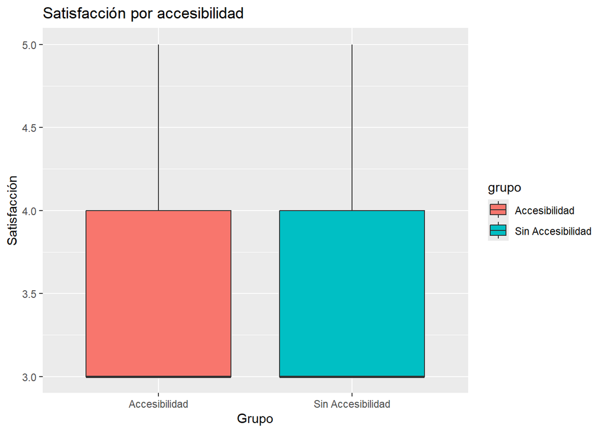

```r
ggplot(datos, aes(x = grupo, y = satisfaction, fill = grupo)) +
  geom_boxplot() +
  labs(title = "Satisfacción por accesibilidad", x = "Grupo", y = "Satisfacción")
```

Observación: - Ambos grupos muestran medias similares, y rangos cercanos. No hay indicios gráficos de diferencia significativa.

## 8.5 Contraste de hipótesis

```r
t.test(satisfaction ~ grupo, data = datos)
```

```
##
##  Welch Two Sample t-test
##
## data:  satisfaction by grupo
## t = -0.65106, df = 4996.9, p-value = 0.515
## alternative hypothesis: true difference in means between group Accesibilidad and group Sin Accesibilidad is not equal to 0
## 95 percent confidence interval:
##  -0.05436677  0.02725892
## sample estimates:
##     mean in group Accesibilidad mean in group Sin Accesibilidad
##                        3.527339                        3.540893
```